# Workshop: Introduction to Data Wrangling I

Rolando J. Acosta

1. Load the `cdc-excess-deaths-data.rda` file in the `datasets` folder and get acquainted with the data.

```r
# -- Loading data
load("../datasets/cdc-excess-deaths-data.rda")

# -- Displaying data
knitr::kable(head(excess_deaths_dat))
```

| Week Ending Date | State | Observed Number | Upper Bound Threshold | Average Expected Count | Type | Outcome |
| --- | --- | --- | --- | --- | --- | --- |
| 2017-01-07 | Alabama | 1121 | 1109 | 1033 | Predicted (weighted) | All causes |
| 2017-01-14 | Alabama | 1130 | 1116 | 1044 | Predicted (weighted) | All causes |
| 2017-01-21 | Alabama | 1048 | 1118 | 1048 | Predicted (weighted) | All causes |
| 2017-01-28 | Alabama | 1026 | 1115 | 1045 | Predicted (weighted) | All causes |
| 2017-02-04 | Alabama | 1036 | 1113 | 1041 | Predicted (weighted) | All causes |
| 2017-02-11 | Alabama | 1058 | 1112 | 1040 | Predicted (weighted) | All causes |

2. Change the name of the columns to: `date`, `state`, `deaths`, `threshold`, `average`, `type`, `outcome`.

```r
# -- Changing the variable names
excess_deaths_dat <- excess_deaths_dat %>%
  setNames(c("date", "state", "deaths", "threshold", "average", "type", "outcome"))

# -- Displaying data
knitr::kable(head(excess_deaths_dat))
```

| date | state | deaths | threshold | average | type | outcome |
| --- | --- | --- | --- | --- | --- | --- |
| 2017-01-07 | Alabama | 1121 | 1109 | 1033 | Predicted (weighted) | All causes |
| 2017-01-14 | Alabama | 1130 | 1116 | 1044 | Predicted (weighted) | All causes |
| 2017-01-21 | Alabama | 1048 | 1118 | 1048 | Predicted (weighted) | All causes |
| 2017-01-28 | Alabama | 1026 | 1115 | 1045 | Predicted (weighted) | All causes |
| 2017-02-04 | Alabama | 1036 | 1113 | 1041 | Predicted (weighted) | All causes |
| 2017-02-11 | Alabama | 1058 | 1112 | 1040 | Predicted (weighted) | All causes |

3. Create a figure where you plot `date` on the *x-axis* and `deaths` on the *y-axis* for Puerto Rico. Only use *unweighted* data. Label the axes accordingly and add a title to the figure.

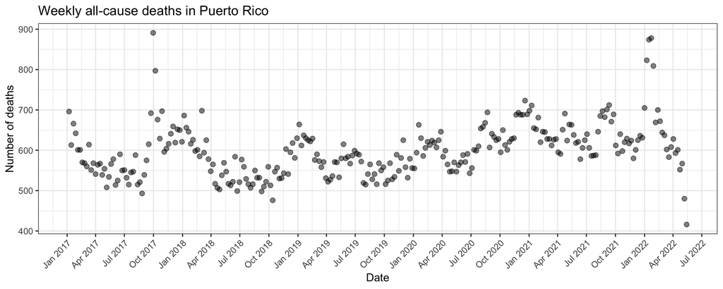

```r
# -- Code to create figure
excess_deaths_dat %>%
  filter(state == "Puerto Rico",
         type  == "Unweighted") %>%
  ggplot(aes(date, deaths)) +
  geom_point(alpha = 0.50,
             size  = 2) +
  scale_x_date(date_labels = "%b %Y",
               date_breaks = "3 months") +
  labs(x     = "Date",
       y     = "Number of deaths",
       title = "Weekly all-cause deaths in Puerto Rico") +
  theme_bw() +
  theme(axis.text.x = element_text(angle = 45, hjust = 1))
```

- What do you notice?

*A few bumps in the number of deaths*

*A big decrease in the number of deaths towards the end of the time series*

- Can you explain the bumps?

*There is a huge increase in the number of deaths around October 2017 which is associated with Hurricane Maria*

*The increase around January 2019 is normal and associated with seasonal behavior*

*Starting in July 2020, there is an increase in the number of deaths associated with COVID-19*

- What’s happening towards the end of the time series?

*The decrease is explained by reporting lags*

- How can you fix it?

*Implement a weighting scheme*

*Don’t use recent data*

4. Create a new data set with data until the end of March 2022. Create a figure where you plot `date` on the *x-axis* and `deaths` on the *y-axis* for Puerto Rico using the newly created dataset. Only use *unweighted* data. Label the axes accordingly and add a title to the figure.

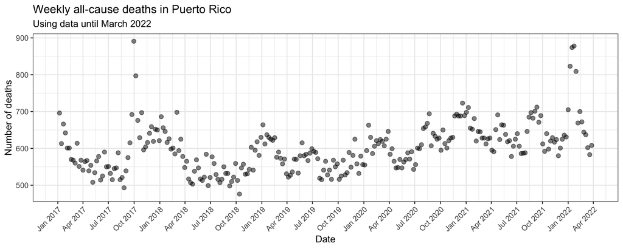

```r
# -- Subsetting data
excess_deaths_subdat <- excess_deaths_dat %>%
  filter(date <= "2022-03-31")

# -- Code to create figure
excess_deaths_subdat %>%
  filter(state == "Puerto Rico",
         type  == "Unweighted") %>%
  ggplot(aes(date, deaths)) +
  geom_point(alpha = 0.50,
             size  = 2) +
  scale_x_date(date_labels = "%b %Y",
               date_breaks = "3 months") +
  labs(x        = "Date",
       y        = "Number of deaths",
       title    = "Weekly all-cause deaths in Puerto Rico",
       subtitle = "Using data until March 2022") +
  theme_bw() +
  theme(axis.text.x = element_text(angle = 45, hjust = 1))
```